# Visualization with ggplot2

### How to utilize R package ggplot2 to create data visualizations:

Inspired by [this](https://www.r-bloggers.com/data-visualization-in-r-using-ggplot2/) blog post.

## What is ggplot2?

*ggplot2* is a package that can be installed in R to create *visualizations* out of given *data*. The idea for ggplot2 originated out of the concept of separating plots into three separate parts: * data * aesthetics * geometry

## What kinds of visualizations?

Some examples of plots you can create with ggplot2 include scatter plots, line plots, bar charts, histograms, box plots, or pie charts. Each of these kinds of visualizations contain their own functions such as, but not limited to, *geom_point()*, *geom_line()*, and *coord_polar()*.

## Example:

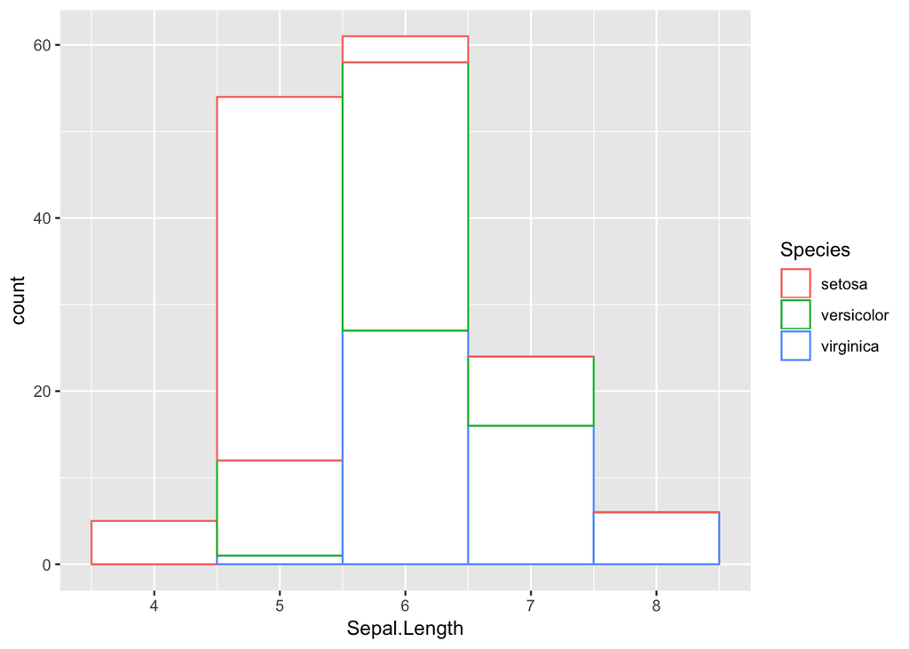

```r
library(ggplot2)

ggplot(iris, aes(x=Sepal.Length, color=Species)) +
geom_histogram(fill="white", binwidth = 1)
```

## For more help:

For more information, take a look at [this](https://ggplot2.tidyverse.org/) website.